# Sistema di raccomandazione

### **4 Analisi dei dati**

*Per l’anailisi dei dati assumiamo che se un item ha avuto un certo numero di valutazioni X, allora il numero di visualizzazioni sarà maggiore uguale a X (tenendo in considerazione il fatto che molti utenti che hanno visto un prodotto non hanno espresso una valutazione); di conseguenza se un item è visto maggiormente, probabilmente, avrà anche buone valutazioni.*

I 100 items più valutati dagli utenti sono: *(Sono mostrati solo i primi 10 per numero di valutazioni)*

```r
top_n<-Rating %>% count(Rating$ID)
top_n<-top_n %>% arrange(desc(n))
top_n<-head(top_n,100)
colnames(top_n)[1]="ID"
colnames(top_n)[2]="Valutazioni"
top_n=merge(top_n,Anime,by="ID")
top_n=top_n[order( top_n[,2],decreasing = TRUE) ,]

kable(head(top_n[,3:2],10))
```

| Name | Valutazioni |
| --- | --- |
| Death Note | 182375 |
| Attack on Titan | 169794 |
| Sword Art Online | 161192 |
| Angel Beats! | 141127 |
| One Punch Man | 138924 |
| Code Geass:Lelouch of the Rebellion | 137291 |
| Toradora! | 135524 |
| Fullmetal Alchemist:Brotherhood | 134197 |
| No Game, No Life | 129009 |
| Tokyo Ghoul | 128822 |

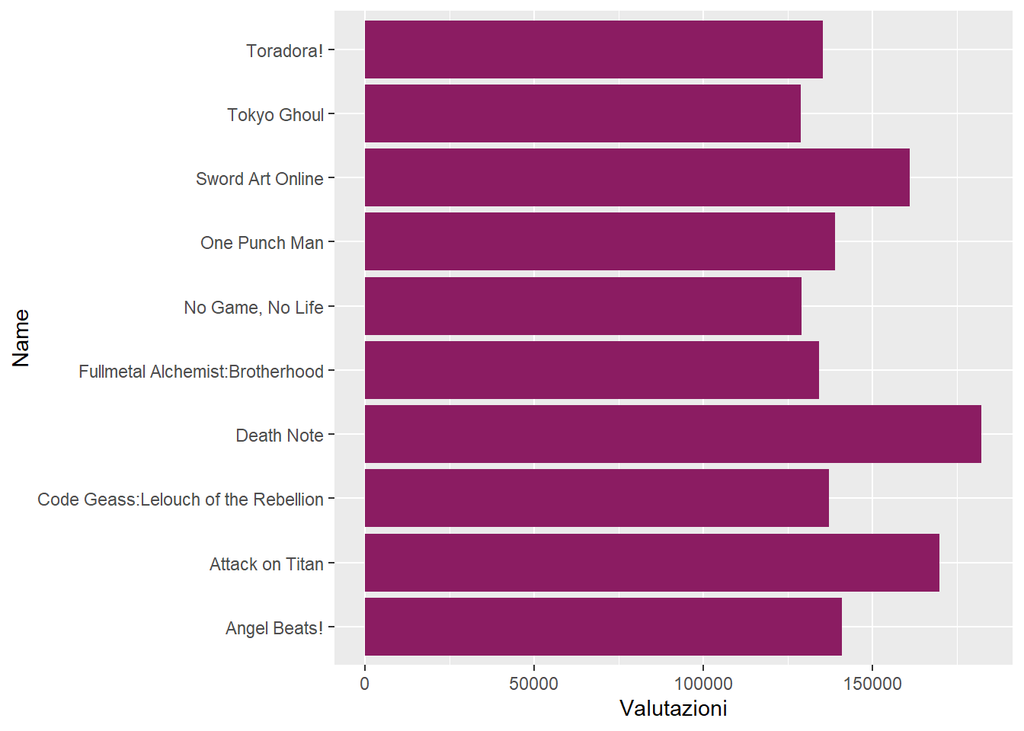

Osserviamo la **media** delle valutazioni fornite dagli utenti.

```
## [1] 8
```

La media arrotondata delle valutazioni è **8**; quindi, in generale se un item ha molte valutazioni (dunque, se è maggiormente visto) generalmente tende ad avere una valutazione positiva.

Vediamo quale sono le tipologie di opere da cui sono ispirati gli anime.

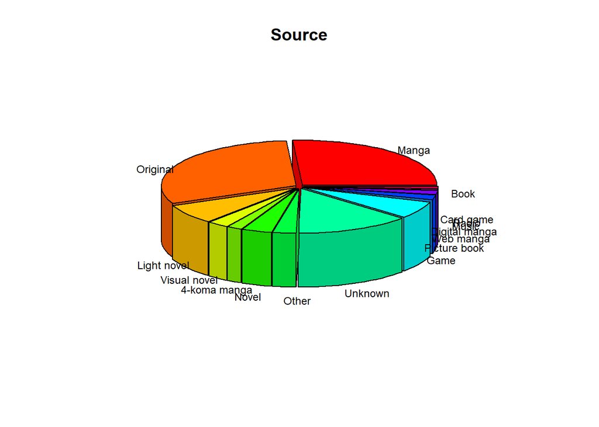

```r
slices <- c(sum(Anime$Source=="Manga"), sum(Anime$Source=="Original"), sum(Anime$Source=="Light novel"), sum(Anime$Source=="Visual novel"), sum(Anime$Source=="4-koma manga"),sum(Anime$Source=="Novel"),sum(Anime$Source=="Other")
,sum(Anime$Source=="Unknown"),sum(Anime$Source=="Game"),sum(Anime$Source=="Picture book"),sum(Anime$Source=="Web manga"),sum(Anime$Source=="Digital manga"),sum(Anime$Source=="Music"),sum(Anime$Source=="Radio"),sum(Anime$Source=="Card game"),sum(Anime$Source=="Book"))


lbls <- c("Manga", "Original", "Light novel", "Visual novel", "4-koma manga","Novel","Other","Unknown","Game","Picture book","Web manga","Digital manga","Music","Radio","Card game","Book")

pie3D(slices,labels=lbls,explode=0.03,main="Source",radius = 1,height = 0.2,labelcex = 0.75,)
```

**Notiamo che** la maggior parte degli anime sono opere prime e originali oppure ispirate a manga. Inoltre, c’è una grossa fetta di grafico, ovvero “Unknown”, che rappresenta tutti gli anime di cui si sa poco riguardo l’opera originaria.

Diamo un’occhiata agli **studi di produzione**

| Studios | Production |
| --- | --- |
| Unknown | 1707 |
| Toei Animation | 293 |
| Sunrise | 220 |
| J.C.Staff | 181 |
| Madhouse | 181 |
| Studio Deen | 145 |
| Production I.G | 131 |
| Studio Pierrot | 125 |
| A-1 Pictures | 119 |
| OLM | 107 |
| TMS Entertainment | 103 |
| Nippon Animation | 89 |
| Bones | 75 |
| Gonzo | 74 |
| Kyoto Animation | 71 |

Sfortunatamente per molti items non conosciamo lo studio di produzione e consideriamo, dunque, Toei Animation lo studio più “produttivo”

### **5 Confronto tra gli algoritmi di raccomandazione tradizionali**

Si vuole creare un **sistema di raccomandazione** collaborative filtering confrontando gli algoritmi tradionali offerti dalla libreria “recommenderlab” e scegliendo quello con le prestazioni migliori sul dataset in esame. In particolare saranno presi in considerazione i seguenti algoritmi:

- UBCF
- SVD
- POPULAR
- RANDOM

Il dataset in esame contiente una grande quantità di dati ma molti di questi non hanno una reale rilevanza statistica; di conseguenza, è utile e necessario, per ridurre i tempi di addestramento e predizione, effettuare una serie di operazioni per ridurre le dimensioni del dataset.

Consideriamo il dataset dei rating

| user_id | ID | rating |
| --- | --- | --- |
| 3 | 1 | 9 |
| 6 | 1 | 6 |
| 14 | 1 | 9 |
| 19 | 1 | 8 |
| 22 | 1 | 9 |
| 23 | 1 | 9 |

Per utilizzare la libreria “*recommenderlab*” è necessario convertire la matrice in un oggetto del tipo “realRatingMatrix”.

```
## 10 x 30 sparse Matrix of class "dgCMatrix"
```

```
##    [[ suppressing 30 column names '1', '5', '6' ... ]]
```

```
##
## 0  . . . . . . .  . . .  . . . . . . . . . . . . . . . . . . . .
## 1  . . . . . . 9 10 . 9  . . . . . . . . . . . . . . . . . . . .
## 2  . . . . . . .  9 . .  . . . . . . . . . . . . . . . . . . . .
## 3  9 . . . . . .  . . .  . . . . . 8 . . . 8 . . . 9 . . . . . .
## 4  . . . . . 9 .  . . .  . . . . . . . . . . . . . . . . . . . .
## 5  . . . . . . .  . . . 10 . . . . . . . . . . . . . . . . . . .
## 6  6 . . . . . .  5 . .  . . . . . 8 . 9 . 9 . . . . . . . 7 . .
## 7  . . . . . . .  . . .  . . . . . . . . . . . . . . . . . . . .
## 8  . . . . . . .  . . .  . . . . . 9 8 . . . . . . . . . . . . .
## 10 . . . . . . .  . . .  . . . . . . . . . . . . . . . . . . . .
```

Prendiamo in considerazione solo gli utenti che hanno espresso almeno **15** pareri e gli items che hanno ricevuto almeno **250** valutazioni..

```r
sampled<-r[rowCounts(r)>15,colCounts(r)>250] #capire che fa
```

Riduciamo ulteriormente la dimensione del datasetdei rating, estraendo una percentuale (pari al **1%**) di records casuali.

Adesso, il dataset contiene le valutazioni di **2680** utenti su **4066** items.

Per il confronto tra i vari algoritmi è particolarmente utile creare uno **“schema di valutazione”**.

Proviamo ad eseguire diversi algoritmi sul nostro dataset più volte, modificando i parametri degli schemi.

- method = validation con k=10
- train = 85%
- GoodRating= 4
- Items conosciuti per utente = 3

```
## UBCF run fold/sample [model time/prediction time]
##   1  [0.05sec/15.96sec]
##   2  [0.03sec/15.03sec]
##   3  [0.05sec/16.67sec]
##   4  [0.04sec/14.5sec]
##   5  [0.03sec/15.91sec]
##   6  [0.04sec/15.55sec]
##   7  [0.03sec/15.78sec]
##   8  [0.03sec/16.22sec]
##   9  [0.03sec/16.14sec]
##   10  [0.03sec/16.51sec]
## SVD run fold/sample [model time/prediction time]
##   1  [1.68sec/0.54sec]
##   2  [1.88sec/0.62sec]
##   3  [1.98sec/0.7sec]
```

[output cut: 29 more lines]

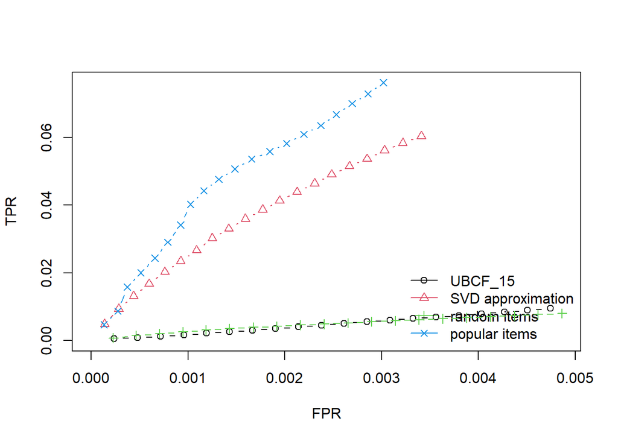

- method = validation con k=10
- train = 85%
- GoodRating= 4
- Items conosciuti per utente = 5

```
## UBCF run fold/sample [model time/prediction time]
##   1  [0.05sec/17.43sec]
##   2  [0.04sec/17.85sec]
##   3  [0.04sec/16.04sec]
##   4  [0.04sec/16.25sec]
##   5  [0.03sec/16.35sec]
##   6  [0.05sec/15.84sec]
##   7  [0.03sec/15.88sec]
##   8  [0.04sec/16.03sec]
##   9  [0.05sec/15.77sec]
##   10  [0.03sec/15.81sec]
## SVD run fold/sample [model time/prediction time]
##   1  [1.67sec/0.46sec]
##   2  [1.81sec/0.53sec]
##   3  [1.65sec/0.52sec]
```

[output cut: 29 more lines]

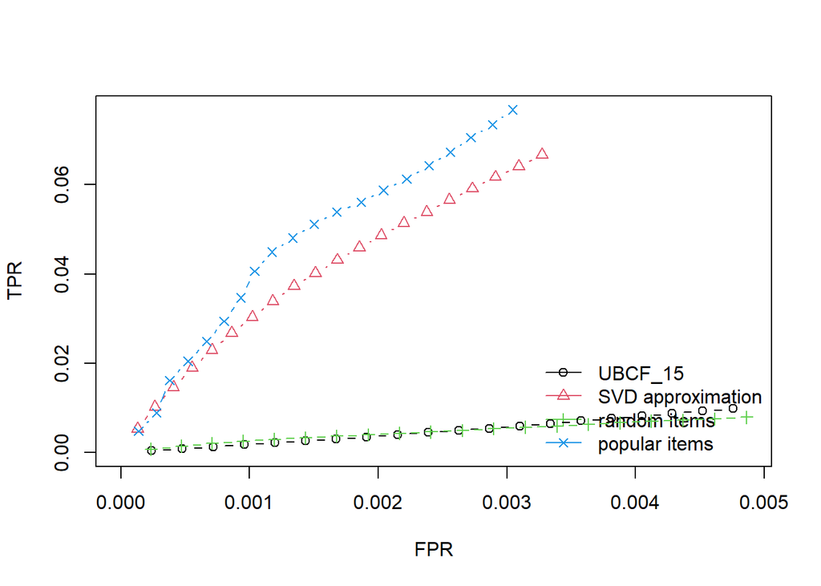

- method = validation con k=10
- train = 85%
- GoodRating= 4
- Items conosciuti per utente = 7

```
## UBCF run fold/sample [model time/prediction time]
##   1  [0.02sec/17.61sec]
##   2  [0.05sec/17.43sec]
##   3  [0.04sec/18.2sec]
##   4  [0.03sec/18.47sec]
##   5  [0.03sec/18.55sec]
##   6  [0.05sec/18.31sec]
##   7  [0.05sec/18.17sec]
##   8  [0.04sec/21.07sec]
##   9  [0.09sec/21.67sec]
##   10  [0.04sec/26.05sec]
## SVD run fold/sample [model time/prediction time]
##   1  [3.38sec/0.89sec]
##   2  [2.39sec/0.96sec]
##   3  [2.42sec/0.57sec]
```

[output cut: 29 more lines]

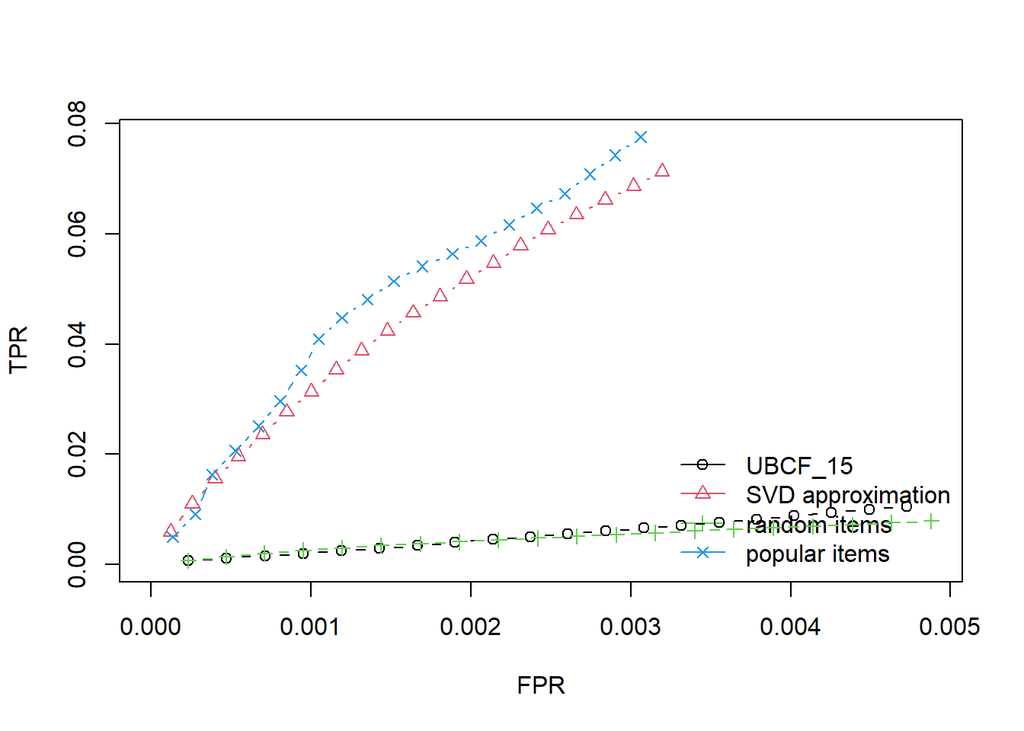

- method = validation con k=10
- train = 85%
- GoodRating= 4
- Items conosciuti per utente = 10

```
## UBCF run fold/sample [model time/prediction time]
##   1  [0.05sec/22.32sec]
##   2  [0.05sec/37.79sec]
##   3  [0.05sec/38.7sec]
##   4  [0.08sec/37.36sec]
##   5  [0.06sec/37.8sec]
##   6  [0.08sec/36sec]
##   7  [0.05sec/35.66sec]
##   8  [0.07sec/36.12sec]
##   9  [0.08sec/34.67sec]
##   10  [0.09sec/36.8sec]
## SVD run fold/sample [model time/prediction time]
##   1  [4.09sec/1.03sec]
##   2  [3.11sec/1.04sec]
##   3  [3.69sec/1.1sec]
```

[output cut: 29 more lines]

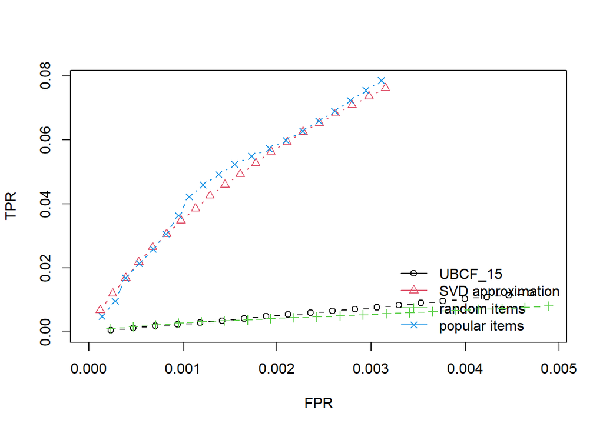

- method = validation con k=10
- train = 75%
- GoodRating= 4
- Items conosciuti per utente = 10

```
## UBCF run fold/sample [model time/prediction time]
##   1  [0.09sec/33.82sec]
##   2  [0.07sec/35.35sec]
##   3  [0.06sec/35.98sec]
##   4  [0.07sec/36.78sec]
##   5  [0.07sec/36.03sec]
##   6  [0.07sec/32.2sec]
##   7  [0.06sec/31.74sec]
##   8  [0.07sec/34.44sec]
##   9  [0.05sec/24.14sec]
##   10  [0.07sec/22.37sec]
## SVD run fold/sample [model time/prediction time]
##   1  [2.42sec/0.66sec]
##   2  [2.03sec/0.67sec]
##   3  [2.13sec/0.52sec]
```

[output cut: 29 more lines]

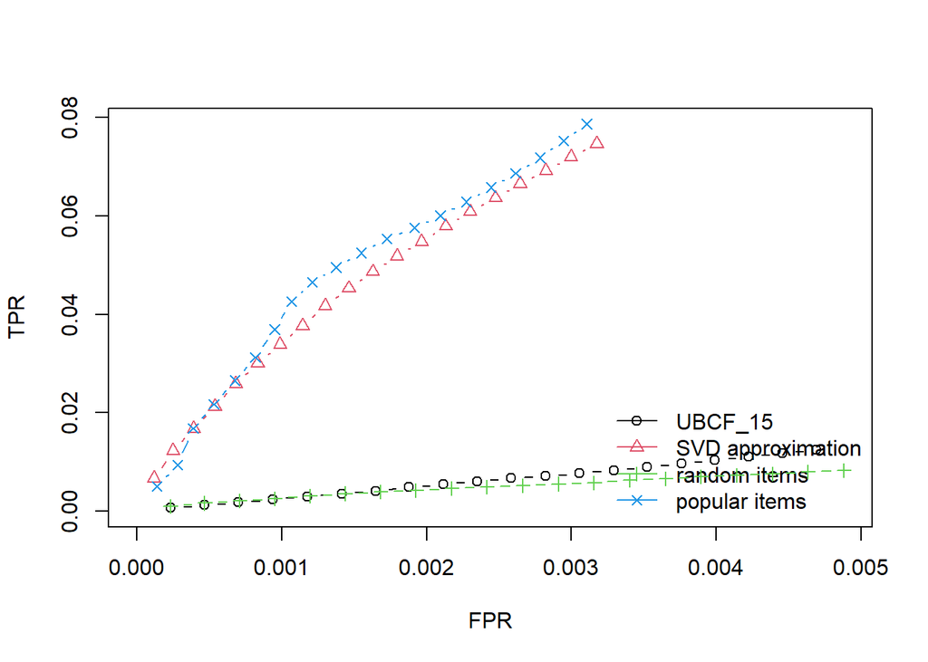

- method = validation con k=10
- train = 90%
- GoodRating= 4
- Items conosciuti per utente = 10

```
## UBCF run fold/sample [model time/prediction time]
##   1  [0.05sec/33.71sec]
##   2  [0.08sec/33.8sec]
##   3  [0.07sec/34.44sec]
##   4  [0.04sec/32.93sec]
##   5  [0.08sec/33.5sec]
##   6  [0.06sec/33.16sec]
##   7  [0.06sec/32.3sec]
##   8  [0.07sec/32.75sec]
##   9  [0.06sec/32.25sec]
##   10  [0.08sec/33.17sec]
## SVD run fold/sample [model time/prediction time]
##   1  [3.45sec/0.91sec]
##   2  [3.31sec/0.99sec]
##   3  [3sec/0.78sec]
```

[output cut: 29 more lines]

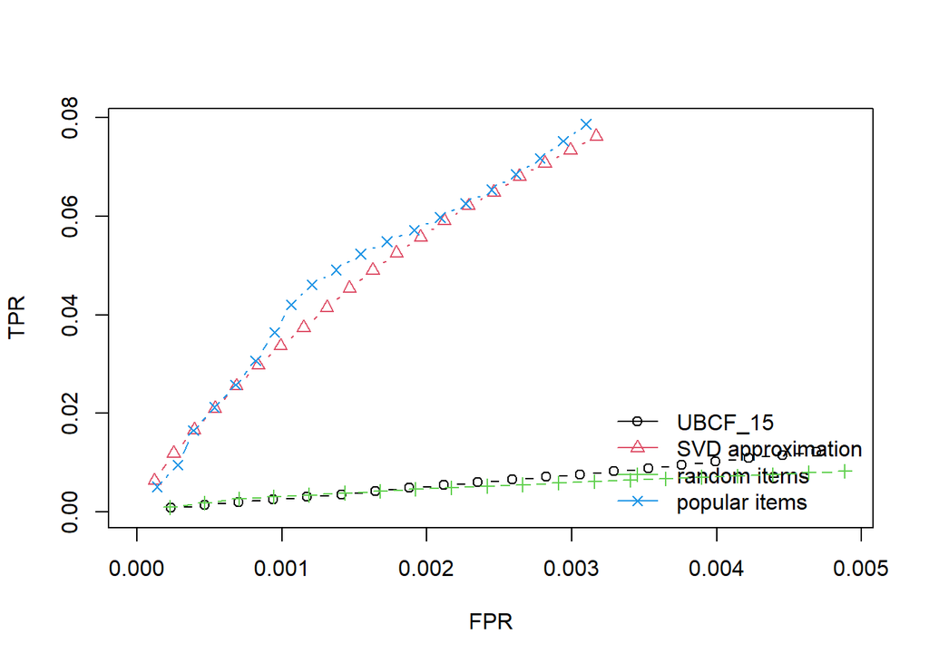

- method = validation con k=10
- train = 85%
- GoodRating= 7
- Items conosciuti per utente = 10

```
## UBCF run fold/sample [model time/prediction time]
##   1  [0.07sec/32.48sec]
##   2  [0.08sec/32.72sec]
##   3  [0.07sec/32.64sec]
##   4  [0.07sec/32.25sec]
##   5  [0.06sec/32.53sec]
##   6  [0.04sec/32.19sec]
##   7  [0.07sec/32.64sec]
##   8  [0.06sec/32.96sec]
##   9  [0.07sec/32.63sec]
##   10  [0.08sec/33.26sec]
## SVD run fold/sample [model time/prediction time]
##   1  [3.1sec/0.97sec]
##   2  [2.79sec/0.94sec]
##   3  [3.45sec/0.86sec]
```

[output cut: 29 more lines]

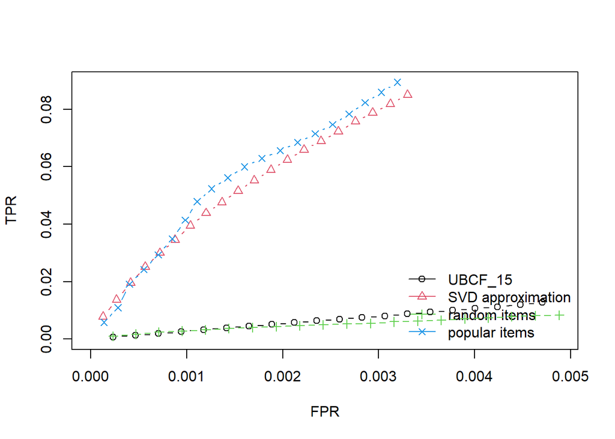

- method = validation con k=10
- train = 85%
- GoodRating= 10
- Items conosciuti per utente = 12

```
## UBCF run fold/sample [model time/prediction time]
##   1  [0.07sec/30.18sec]
##   2  [0.07sec/32.88sec]
##   3  [0.06sec/32.35sec]
##   4  [0.06sec/32.47sec]
##   5  [0.05sec/34.28sec]
##   6  [0.07sec/32.48sec]
##   7  [0.04sec/33.59sec]
##   8  [0.06sec/31.5sec]
##   9  [0.06sec/33.01sec]
##   10  [0.05sec/32.28sec]
## SVD run fold/sample [model time/prediction time]
##   1  [3.12sec/0.99sec]
##   2  [3.32sec/0.92sec]
##   3  [3.71sec/0.79sec]
```

[output cut: 29 more lines]

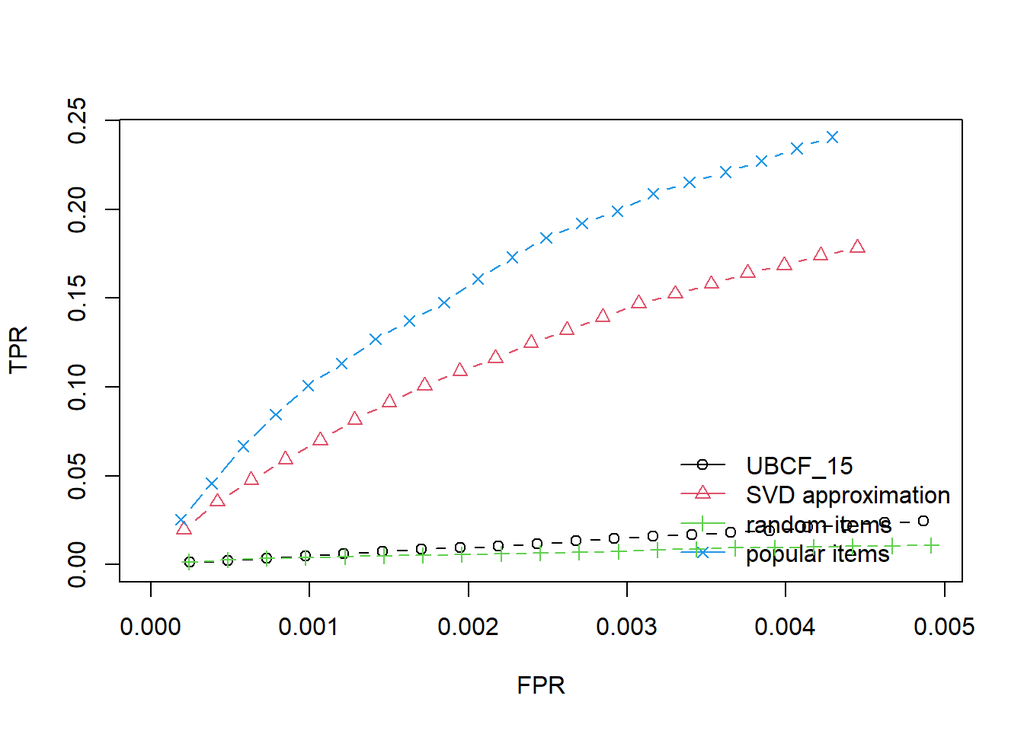

- method = validation con k=10
- train = 85%
- GoodRating= 10
- Items conosciuti per utente = 15

```
## UBCF run fold/sample [model time/prediction time]
##   1  [0.06sec/25.84sec]
##   2  [0.04sec/25.59sec]
##   3  [0.05sec/26.29sec]
##   4  [0.05sec/27.46sec]
##   5  [0.06sec/24sec]
##   6  [0.05sec/23.73sec]
##   7  [0.04sec/23.43sec]
##   8  [0.05sec/23.4sec]
##   9  [0.04sec/23.64sec]
##   10  [0.03sec/23.43sec]
## SVD run fold/sample [model time/prediction time]
##   1  [3.1sec/0.89sec]
##   2  [2.72sec/0.81sec]
##   3  [2.86sec/0.75sec]
```

[output cut: 29 more lines]

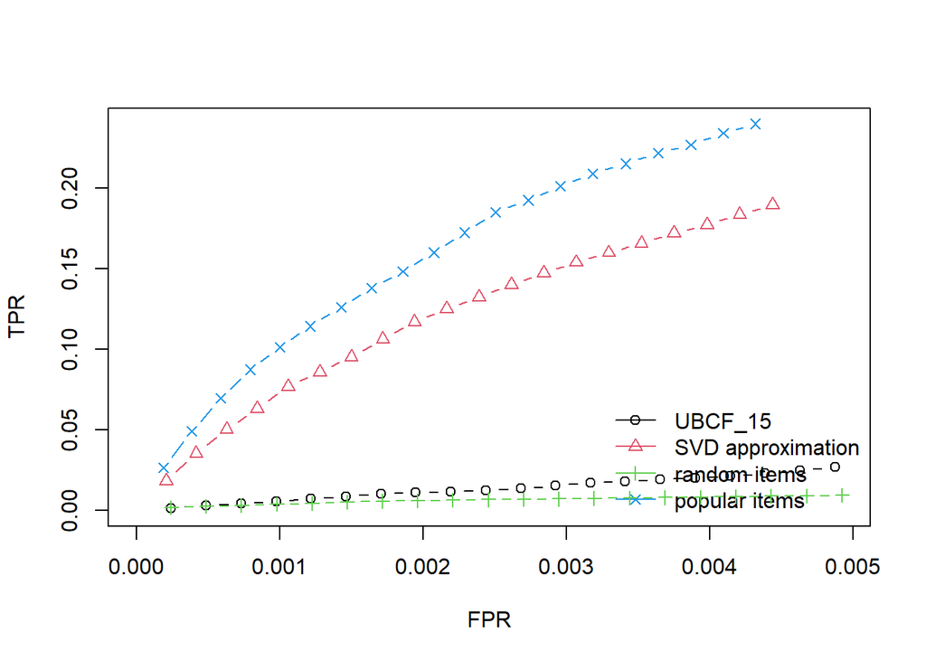

- method = validation con k=10
- train = 85%
- GoodRating= 2
- Items conosciuti per utente = 15

```
## UBCF run fold/sample [model time/prediction time]
##   1  [0.05sec/36.19sec]
##   2  [0.05sec/36.89sec]
##   3  [0.04sec/39.27sec]
##   4  [0.06sec/37.86sec]
##   5  [0.04sec/35.28sec]
##   6  [0.05sec/49.43sec]
##   7  [0.08sec/52.11sec]
##   8  [0.05sec/54.96sec]
##   9  [0.06sec/54.41sec]
##   10  [0.06sec/50.88sec]
## SVD run fold/sample [model time/prediction time]
##   1  [2.93sec/1.66sec]
##   2  [2.72sec/1.76sec]
##   3  [3.45sec/1.6sec]
```

[output cut: 29 more lines]

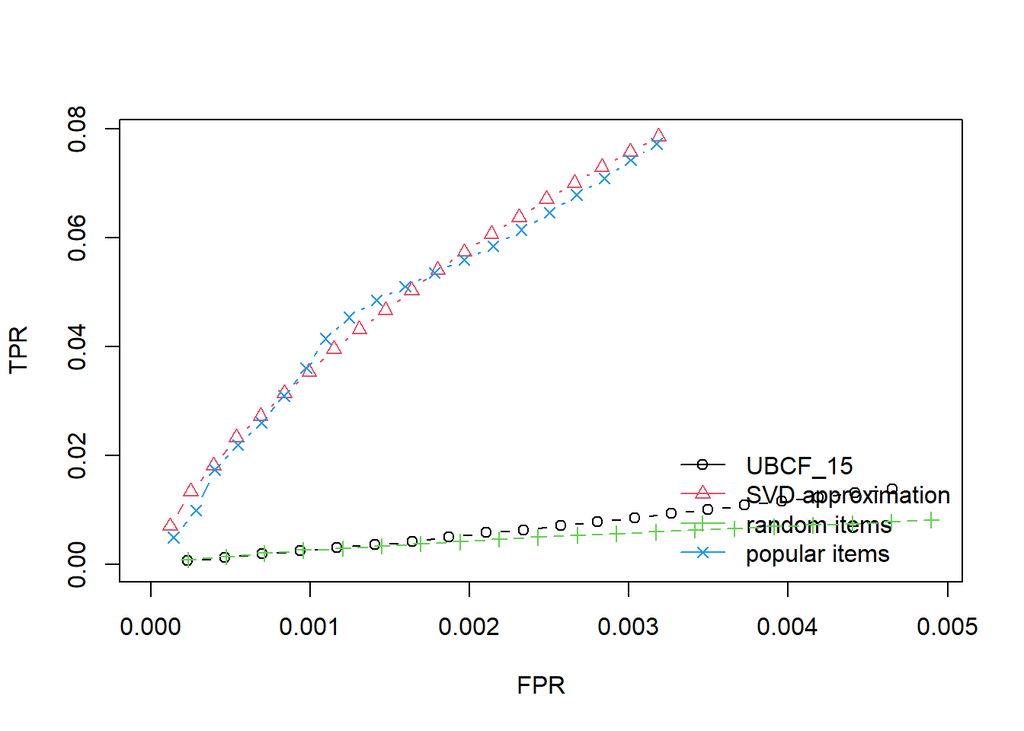

Per quanto riguarda i **tempi di esecuzione** (training e predizione) restano pressochè uguali per ogni esecuzione. In genere, **UBCF**, oltre a fornire risultati peggiori (insieme **RANDOM**), ha i tempi più lunghi

Indipendentemente dalla percentuale di dati utilizzati per il training, **POPULAR** e **SVD** si comportano mediamente bene (mantenendo la qualità dei risultati comunque “bassa”) ma **POPULAR** tende ad essere generalmente migliore rispetto a **SVD** (anche se, con l’aumentare del numero di items per utenti, si avvicina sempre di più a **POPULAR**)

Notiamo, inolre, che aumentando il parametro “*GoodRating*”, la distanza tra **SVD** e **POPULAR** aumenta. (Fornendo risultati leggermente migliori)

Dato che **SVD** e **POPULAR** sono i due migliori algoritmi, proviamo a testare una versione “**ibrida**”, cercando di ottenere risultati migliori.

```
## HYBRID run fold/sample [model time/prediction time]
##   1  [2.93sec/13.44sec]
##   2  [3.33sec/12.89sec]
##   3  [3.11sec/13.11sec]
##   4  [3.29sec/13.43sec]
##   5  [3.25sec/13.01sec]
##   6  [2.87sec/13.39sec]
##   7  [2.88sec/13.85sec]
##   8  [3.2sec/13.16sec]
##   9  [3.23sec/13.02sec]
##   10  [3.13sec/13.7sec]
```

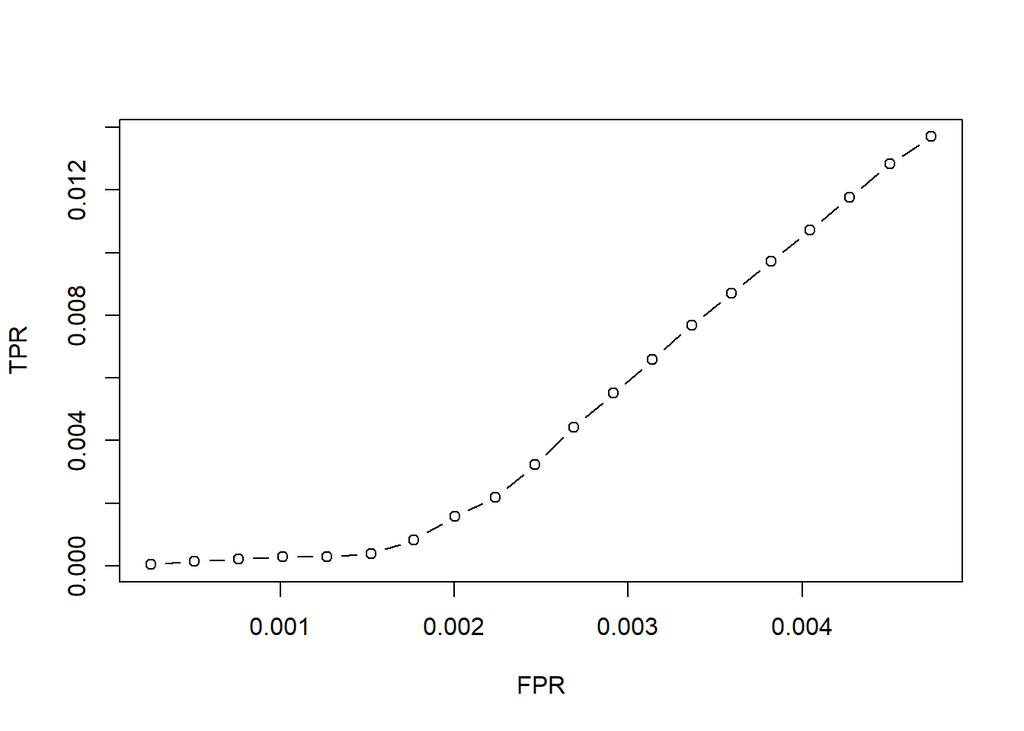

Sfortunatamente, notiamo che unire i due algoritmi **peggiora** il risultato anzichè migliorarlo.

### **6 Implementazione pratica dell’algoritmo**

A questo punto, proviamo a implementare l’algoritmo migliore (trovato precedentemente) e a filtrare i risultati utilizzando strategie *content-based*.

Inanzitutto, implementiamo **SVD** (a causa della sua velocità) consigliando i top **20 item** (che saranno filtrati attraverso metodi content-based). (Saranno visualizzati gli ID degli anime suggeriti).

Per effettuare i test utilizzeremo dei dati che il sistema non ha mai visto e che non sono mai stati utilizzati. (Temporaneamente saranno visualizzati solo gli ID)

```
## $`0`
##  [1] "30"    "32"    "1"     "47"    "227"   "43"    "1535"  "11757" "339"
## [10] "523"   "226"   "1943"  "2476"  "4224"  "16498" "5114"  "205"   "32281"
## [19] "2759"  "437"
##
## $`1`
##  [1] "2904"  "226"   "38524" "32182" "9989"  "9756"  "37510" "11741" "934"
## [10] "10087" "13601" "164"   "28223" "26055" "4181"  "18115" "30654" "31478"
## [19] "14513" "6746"
##
## $`2`
##  [1] "5114"  "25777" "2476"  "10087" "11741" "38524" "813"   "199"   "35760"
## [10] "13601" "121"   "32"    "31240" "36456" "4898"  "11771" "2001"  "269"
## [19] "7724"  "37510"
##
## $`3`
##  [1] "4181"  "16498" "199"   "5114"  "28851" "9756"  "1535"  "2001"  "25777"
## [10] "164"   "32182" "2236"  "13125" "38524" "12355" "16782" "33486" "34599"
## [19] "31964" "7311"
##
## $`4`
##  [1] "2476"  "226"   "10620" "16498" "11111" "5114"  "11757" "9253"  "4181"
## [10] "6547"  "31240" "25777" "934"   "10087" "13601" "2167"  "30276" "11741"
## [19] "6880"  "32281"
##
## $`5`
##  [1] "2167"  "2476"  "1689"  "4181"  "30"    "9989"  "10620" "6547"  "32281"
## [10] "11111" "6880"  "1535"  "28851" "2904"  "101"   "227"   "1575"  "356"
## [19] "431"   "523"
##
## $`6`
##  [1] "2476"  "1689"  "4224"  "9253"  "5081"  "28851" "32281" "16782" "23273"
## [10] "47"    "2966"  "7311"  "31240" "13601" "10087" "12189" "11111" "11741"
## [19] "14813" "2924"
##
## $`7`
##  [1] "32281" "9989"  "1689"  "28851" "23273" "9253"  "1575"  "10087" "2904"
## [10] "25777" "16782" "31240" "11741" "2001"  "1"     "13601" "31964" "2236"
## [19] "30276" "164"
##
## $`8`
##  [1] "1689"  "1"     "227"   "199"   "32"    "47"    "4224"  "43"    "164"
## [10] "1943"  "2236"  "339"   "523"   "9989"  "431"   "205"   "437"   "28851"
## [19] "9756"  "16782"
##
## $`11`
##  [1] "2476"  "226"   "9253"  "31240" "25777" "30276" "11741" "22535" "10087"
## [10] "31043" "13601" "934"   "38524" "5081"  "33486" "32937" "35760" "4898"
## [19] "30831" "32281"
```

[output not shown]

Consideriamo tutti i rating forniti dagli utenti su cui sono state effettuate le predizioni.

[output not shown]

Associamo ad ogni valutazione le caratteristiche dell’anime corrispondende.

| ID | Users | rating | Name | Genres |
| --- | --- | --- | --- | --- |
| 1 | 6 | 6 | Cowboy Bebop | Action, Adventure, Comedy, Drama, Sci-Fi, Space |
| 1 | 3 | 9 | Cowboy Bebop | Action, Adventure, Comedy, Drama, Sci-Fi, Space |
| 100 | 4 | 7 | PrÃ©tear:The New Legend of Snow White | Comedy, Drama, Fantasy, Magic, Romance, Shoujo, Super Power |

Procediamo con la creazione degli **items-profiles**.

```r
Item_profile=read.csv("IP_COMPLETE2.csv")
Item_profile=Item_profile[,-1]
colnames(Item_profile)[1]="ID"
head(Item_profile)
```

```
##   ID Action Adventure Comedy Drama Ecchi Game Harem Music Fantasy Mystery
## 1  1      1         1      1     1     0    0     0     0       0       0
## 2  5      1         0      0     1     0    0     0     0       0       1
## 3  6      1         1      1     1     0    0     0     0       0       0
## 4  7      1         0      0     1     0    0     0     0       0       1
## 5  8      0         1      0     0     0    0     0     0       1       0
## 6 15      1         0      1     0     0    0     0     0       0       0
##   Psychological Romance Slice.of.Life Thriller Demons Horror Military Police
## 1             0       0             0        0      0      0        0      0
## 2             0       0             0        0      0      0        0      0
## 3             0       0             0        0      0      0        0      0
## 4             0       0             0        0      0      0        0      1
## 5             0       0             0        0      0      0        0      0
## 6             0       0             0        0      0      0        0      0
##   Sci.Fi Sports Supernatural Dementia Historical Magic Parody School Shounen
## 1      1      0            0        0          0     0      0      0       0
## 2      1      0            0        0          0     0      0      0       0
## 3      1      0            0        0          0     0      0      0       1
## 4      0      0            1        0          0     1      0      0       0
## 5      0      0            1        0          0     0      0      0       1
## 6      0      1            0        0          0     0      0      0       1
##   Super.Power Mecha Seinen Shoujo Vampire Martial.Arts Samurai Space
## 1           0     0      0      0       0            0       0     1
## 2           0     0      0      0       0            0       0     1
## 3           0     0      0      0       0            0       0     0
## 4           0     0      0      0       0            0       0     0
## 5           0     0      0      0       0            0       0     0
## 6           0     0      0      0       0            0       0     0
```

Creiamo gli **users-profiles**

```r
All_generi=c("User","Action","Adventure","Comedy","Drama", "Ecchi", "Game","Harem","Music","Fantasy","Mystery", "Psychological", "Romance", "Slice of Life","Thriller","Demons","Horror",  "Military",
             "Police","Sci-Fi","Sports","Supernatural","Dementia","Historical","Magic","Parody","School","Shounen","Super Power","Mecha","Seinen","Shoujo","Vampire",
             "Martial Arts","Samurai","Space")
User_Profile=matrix(0,nrow=nrow(User),ncol=36)
colnames(User_Profile)=All_generi
User_Profile[,1]=User[,1]


for(i in 1:nrow(User_Profile)){
 current=mat_merge[mat_merge$Users == User_Profile[i,1],]  ## avrò i rating del'utente corrente
 #scorre user profile
 gener_profile=merge(current,Item_profile,by="ID")
 g <- 2
 for(col in 4:ncol(gener_profile)){
  sum <- 0
  n <- 0
  rating <- 0
  for(row in 1:nrow(gener_profile) ){
   if(gener_profile[row,col]==1){
    sum=sum+gener_profile[row,3]
    n <- n+1
   }
  }
  if(n!=0){
   rating <- sum/n
   User_Profile[i,g] <- round(rating)
  }
  g <- g+1
 }
}
```

Ricalcolo i rating degli items suggeriti da **SVD** utilizzando un approccio content-based e facendo la media tra vecchio rating+nuovo.

```r
utenti=colnames(filter)

for(i in 1:nrow(User_Profile)){
 id=User_Profile[i,1]
 current_top=filter[colnames(filter)==id] #seleziono gli item associati al profilo corrente

 current_top=as.data.frame(current_top)
 colnames(current_top)="ID"
 current_top=merge(current_top,Item_profile,by="ID") ##preno gli item profile di quelli dell'utente

 user=as.vector(User_Profile[i,2:35],mode='numeric')

 for(items in 1:nrow(current_top)){
  item=as.vector(current_top[items,2:35],mode='numeric')
  distanza=(cosine(user,item ))*10
  filter_rating[items,i]=(((filter_rating[items,i]*1)+distanza[1,1]*2)/3)#faccio la media dei rating predetti tra svd e content based
  }#scorro gli item

 rm(current_top)
}
```

Selezioniamo i primi 10 per ogni utente per rating maggiore

```r
for(i in 1:ncol(filter_rating)){
 items_id=as.list(filter[,i])
 items_rating=as.list(filter_rating[,i])

 df <- do.call(rbind, Map(data.frame, A=items_id, B=items_rating))
 colnames(df)[1]="ID"
 colnames(df)[2]="rating"
 df=df[order( df[,2],decreasing = TRUE ),]
 final_for_user=head(df,10)
 #final_for_user=final_for_user[order( final_for_user[,2],decreasing = TRUE ),]
 final_for_user=merge(final_for_user,Anime,by="ID")
 final_for_user=final_for_user[order(final_for_user[,2],decreasing = TRUE) ,]
 #rownames(final_for_user)=c(1:10)
 print(final_for_user[,c(3,4,2)])
}
```

```
##                                             Name
## 4             Evangelion:1.0 You Are (Not) Alone
## 10                                         AKIRA
## 9                             Ghost in the Shell
## 7                                     Your Name.
## 5                        Neon Genesis Evangelion
## 2                                     Death Note
## 6  Neon Genesis Evangelion:The End of Evangelion
## 1                                   Cowboy Bebop
## 8                                      Toradora!
## 3                                           FLCL
##                                                               Genres   rating
## 4                        Action, Sci-Fi, Psychological, Drama, Mecha 6.358198
## 10 Action, Military, Sci-Fi, Adventure, Horror, Supernatural, Seinen 6.019971
## 9               Action, Mecha, Police, Psychological, Sci-Fi, Seinen 5.850009
```

[output cut: 216 more lines]

```r
#Notiamo che items posizionati in fondo alla lista si ritrovano al primo posto
```